# Introduction and objectives

**Jesse Harrison, CSC - IT Center for Science Ltd**

biodt.github.io/slides/webinars/harrison-130722.html

# Talk outline

**1. Background**

DT concept in BioDT

**2. Objectives**

Project goals and outcomes

**3. BioDT Use Cases**

Practical applications

# The DT concept in BioDT

### [**Virtual representation(s) of real-world entities and processes,**](https://www.digitaltwinconsortium.org/)

### [**synchronised at a specified frequency and fidelity**](https://www.digitaltwinconsortium.org/)

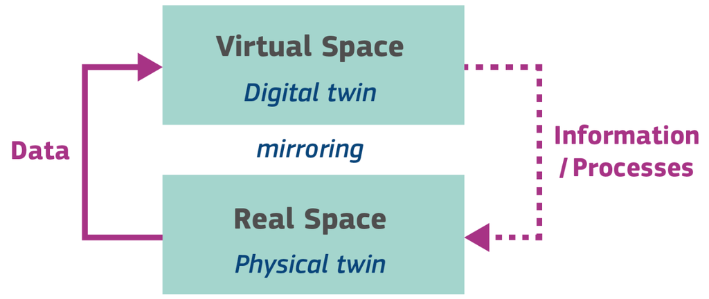

### [Image: digital-strategy.ec.europa.eu](https://digital-strategy.ec.europa.eu/en/library/destination-earth)

# The DT concept in BioDT

- **Industrial** DTs typically facilitate:
  - Product design
  - Operation of machinery
- In **BioDT**, DTs used to:
  - Mimic behaviour observed in nature
  - Meet requirements of BioDT Use Cases
  - Contribute toward EC goal of devising a [full DT of the Earth](https://digital-strategy.ec.europa.eu/en/library/destination-earth)

# General objectives

**Objective 1**

Build and deploy pre-operational BioDT platform

**Objective 2**

Integration with RI platforms and workflows

**Objective 3**

Interoperability with European DT initiatives  
(including [DestinE](https://digital-strategy.ec.europa.eu/en/policies/destination-earth)) and [European Data Infrastructure](https://www.csc.fi/en/-/eudat-data-services-and-international-collaboration-for-research)

# Specific objectives and outcomes

**1: Pre-operational BioDT platform**

- Platform established on [LUMI](https://docs.lumi-supercomputer.eu/)
- Case studies for model development
- Model development¹ and validation

| Outcome | Description |
| --- | --- |
| *1* | Prototype available *as service* |
| *2* | Eight case studies |
| *3* | Improved model predictive performance |
| *4* | Increased model accuracy and precision |

¹ Incl. upscaling for HPC, features for interactive use

# Specific objectives and outcomes

**2: Integration with RIs**

- APIs, user authentication and access
- Interoperability: data, software, practices
- Uptake, new user communities, training¹

| Outcome | Description |
| --- | --- |
| *1* | APIs for feeding data to BioDT platform |
| *2* | FAIR datasets using cross-RI standards and [FDOs](https://fairdigitalobjectframework.org/) |
| *3* | Quality indicators, e.g. FAIRness, geographic accuracy |
| *4* | Training materials and interoperability workshops |

¹ e.g. *Bring Your Own Data* hackathons

# Specific objectives and outcomes

**3: Interoperability with DT initiatives (incl. DestinE) and EDI**

- Cross-DT synchronisation and showcases
- [EOSC](https://ec.europa.eu/info/research-and-innovation/strategy/strategy-2020-2024/our-digital-future/open-science/european-open-science-cloud-eosc_en) data integration, openly available results
- Harmonised data and data governance ([EU Data Spaces](https://digital-strategy.ec.europa.eu/en/policies/strategy-data))

| Outcome | Description |
| --- | --- |
| *1* | BioDT data outputs to DestinE |
| *2* | Interfaces and data integration for interaction with EOSC |
| *3* | Integration of DestinE output data for use by BioDT |
| *4* | Synchronisation with other DT initiatives (e.g. ocean DT) |

# BioDT Use Cases: overview

### Use Cases split into four groups

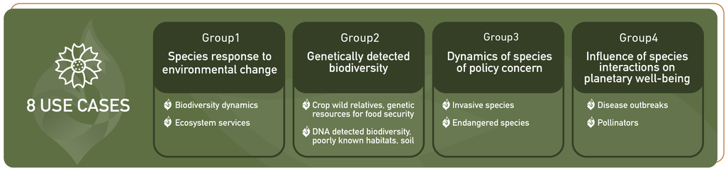

### Data from four RIs:

### DISSCo, eLTER, GBIF, LifeWatch

# UC Group 1: Species response to environmental change

**Current status:**

Existing modelling approaches insufficient

**Approaches:**

Hybrid modelling approaches

Combining biotic and abiotic data

HPC-compatible modelling tools

**Anticipated benefits:**

Improved predictions of shifts in diversity, distribution and abundance

Ability to quantify uncertainty

Tools enabling computationally demanding modelling

# UC Group 1: Species response to environmental change

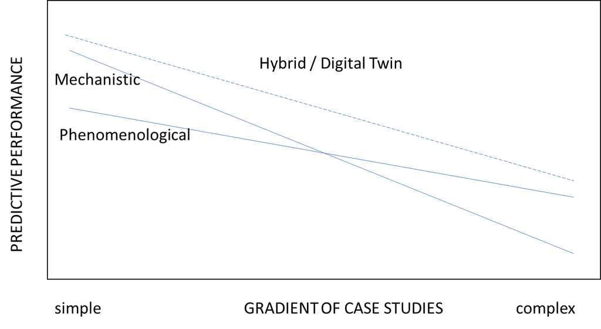

# UC Group 2: Genetically detected biodiversity

**Current status:**

DNA-based methods increasingly needed (e.g. food security)

**Approaches:**

Models involving e.g. crop wild relatives, cryptic habitats

Incorporating DNA-based methods in DTs (e.g. for taxon IDs)

Addressing challenges specific to genetic data

**Anticipated benefits:**

Improved understanding of biodiversity in arable lands and soil

Applied uses (e.g. DNA-based biodiversity monitoring by SMEs)

# UC Group 3: Dynamics of species of policy concern

**Current status:**

No reliable modelling approaches for invasive or endangered species

Challenges: e.g. data scarcity, lag effects

**Approaches:**

Exploiting large-scale spatial and high-resolution temporal data

New generation of predictions for invasive and endangered species

**Anticipated benefits:**

Improved tools to aid evidence-based ecosystem management

# UC Group 4: Influence of species interactions on planetary well-being

**Current status:**

Multiple pressures coinciding with climate change (e.g. pandemics, pollinator loss)

**Approaches:**

Predicting outbreaks using e.g. pathogen distribution data

Modelling pollinator distribution and types

Maps of forage availability in agricultural landscapes

**Anticipated benefits:**

Information on emerging diseases and their locations

Improved knowledge of pollinator responses to environmental change

# Take-home messages

### BioDT will provide infrastructure to:

- Drive long-term biodiversity research
- Maintain commitments to protect biodiversity
- Safeguard societal resilience

# Take-home messages

### BioDT will be used to:

- Better observe spatiotemporal changes in biodiversity
- Develop an improved mechanistic understanding of these changes
- Push limits of predictive biodiversity modelling

// reveal.js plugins